# Catch maps

# Catch data from the Rockfish Recruitment and Ecosystem Assessment Survey

[link](https://swfsc.noaa.gov/textblock.aspx?Division=FED&ParentMenuId=54&id=19340)

**Project**: This project utilizes data collected by the NOAA NMFS SWFSC Santa Cruz as part of the Rockfish Recruitment and Ecosystem Assessment Survey. The Rockfish Recruitment and Ecosystem Assessment Survey is a long-term ocean-going survey, which commenced in 1983 to monitor the recruitment of pelagic juvenile rockfish and other ecosystem components along the entire coast of California.

**Data**: This project uses catch data dutifly recorded, entered and cleaned by Chief Scientist Keith Sakuma (keith.sakuma@noaa.gov). These data are held in an access database stored on the “CRUISE” shared drive at smb://swc-sc-fs/cruise // MWT // juv_cruise_backup08FEB18 (with the most recent date listed)- note that I am not using *the* most up to date version, as the cruise recently concluded and the data has not been adequately checked and corrected. Note also that this is a backup of the SQL database which is the ultimate source for these data.

Although it is possible to access the data directly from this access database, my Mac doesn’t have Access installed, and my PC laptop does not have 64+ bit version of windows installed– which causes all sorts of issues. Anyways, to circumvent RODBC, I exported the following tables that I needed from the access dataset (juv_cruise_backup08FEB18):

dbo_JUV_HAUL * note: I had to add two zeros to stations (1101 and 1106) to enable eventual conversion of coordinates will need to re add if re-load data (not enough digits to convert from decimal minutes to dec deg ex. 122 instead of 12200) dbo_JUV_CATCH dbo_SPECIES_CODES dbo_STANDARD_STATIONS dbo_NWFSC_STANDARD_STATIONS (in some years, we also surveyed sites typically covered by NWFSC)

For each of these tables, I right-clicked the table name and selected Export// Text File (did *not* select box for export data with formating and layout) and changed the extension to a .csv. I then was brought to a Export Text Wizard box, where I selected “Delimited” (Next), then selected “comma” and checked the box for “Include field names on first row”

### Load libraries

```r
library(tidyverse)
library(sf)
library(ggplot2)
library(ggmap) #requires ggplot2
library(lubridate)
```

Note: depending on your version of R and ggplot, there may be some challenges initially with loading maps via {ggmap}. If you experience problems, try downloading the development version of ggplot2 and ggmap (directly from source) devtools::install_github(“hadley/ggplot2”) devtools::install_github(“dkahle/ggmap”) Note2: Because of projection issues, I am no longer relying on ggmaps for basemaps

### Add trawl information to catch data

First step is to add new column to juv_haul describing the year of the trawl

```r
# add two new columns to juv_haul df: time: parsed time, and year: year of haul
juv_haul <- juv_haul %>% # df that we are working with
    mutate(time= parse_date_time(juv_haul$HAUL_DATE, orders = "mdy HMS")) %>% # this creates a new column of converted dates- from HAUL_DATE
    mutate(year= year(time))
```

### Merge species information and haul information

Next, because these tables are no longer linked in a relational database, I need to merge the species name information to the juv_catch df (common name, sci name, notes) from species_codes df (primary key is “SPECIES”) and haul location information (stations, lat, long, bottom depth) from juv_haul (primary key “haul and cruise”). Additionally, i selected only those rows of data where standard_station==1 (if other than 1, there was an issue with the data, and we do not want to include it in analysis)

```r
catch <- juv_catch %>%  # our main df that we want to add data to
              left_join(select(species_codes, -PACFIN_CODE, -MATURITY_CODES), by="SPECIES")%>% # joined specific columns from our second df, species_codes -col
              left_join(select(juv_haul, CRUISE, HAUL_NO, STATION, DEPTH_STRATA, BOTTOM_DEPTH, PROBLEM, STANDARD_STATION, time, year), by=c("CRUISE", "HAUL_NO")) %>% #  merge station information from juv_haul to juv_catch based on cruise and haul number
              filter(STANDARD_STATION==1) # this selects ONLY those stations that were "standard_stations" note: only those rows with standard_station==1, 0= problem!!!
```

note that we selected only those rows where STANDARD_STATION==1. This includes rows with problem codes 0 or 2. 0 means no problems, and 2= rockfish were subsampled, but otherwise a standard haul. Note that the depth strata code: 1= shallow, 2= std, 3= 90m and 4= other. Our catch df only contains data from depth strata 1 or 2 which is either standard or shallow, so ok!

note that at this point, there are potentially multiple rows for a given station (for those sites that were trawled multiple times in a given year) Stations information– list of stations trawled each year

### Create a df for year and station.

This is a comprehensive list of each station that was trawled in a given year. (We will reference this df later in our plot and for those stations not represented by a given year-station combination in species_yr, will plot as + on final map)- ie areas that were fished but did not encounter a particular spp.

```r
stations_yr <- juv_haul %>% # creates new column of just years using the year() function- extracts year info from time column
    filter(STANDARD_STATION==1) %>% # only include standard stations (ie standard station=1, not 0)- otherwise problem or special tow- don't want
    group_by(year, STATION) %>% # group these data by year and station
    summarise() # col= year, station. For each year a list of (non-repeating) stations sampled and fished correctly
```

### Coordinate information for stations

Next, I need to add latitude and longitude values. Can use sum(is.na(stations$LONGITUDE)) to check to ensure there are still no stations missing lat long data

```r
sum(is.na(stations$LATITUDE))
```

[output not shown]

### Convert station coordinates from decimal minutes to decimal degrees

The below code was how I converted from decimal minutes to decimal degrees, but instead, I am going to use code provided by KS (in chunk) stations<-stations%>% separate(LATITUDE, into = c(“deg_lat”, “min_lat”), sep=2) %>% separate(LONGITUDE, into = c(“deg_long”, “min_long”), sep=3)%>% mutate(deg_lat= as.numeric(deg_lat), min_lat=as.numeric(min_lat), deg_long= as.numeric(deg_long), min_long=as.numeric(min_long)) %>% mutate(min_lat= min_lat/60, min_long=min_long/60) %>% mutate(LATITUDE= deg_lat+min_lat, LONGITUDE=deg_long + min_long) %>% mutate(LATITUDE= round(as.numeric(LATITUDE), digits = 3))%>% mutate(LONGITUDE= -(round(as.numeric(LONGITUDE), digits = 3)))%>% select(-c(deg_lat, min_lat, deg_long, min_long))

The following code was created by Kevin Stierhoff and provides better resolution for position information

```r
stations <- stations %>%
            rename(y = LATITUDE, x = LONGITUDE) %>%
            mutate(lat.d  = as.numeric(str_sub(y, 1, 2)),
            lat.m  = as.numeric(str_sub(y, 3, 7)),
            LATITUDE    = lat.d + lat.m/60,
            long.d = as.numeric(str_sub(x, 1, 3)),
            long.m = as.numeric(str_sub(x, 4, 8)),
            LONGITUDE = -(long.d + long.m/60)) %>%
            select(-c(lat.d, long.d, lat.m, long.m))
```

### Combine coordinate information with list of stations trawled in a given year

```r
stations_yr <- stations_yr %>%
              left_join(select(stations, STATION_BOTTOM_DEPTH, LATITUDE, LONGITUDE, STATION, AREA), by="STATION") # joined cols from stations to our list of stations trawled each year.
rm(stations, nwfsc_stations, swfsc_stations, juv_haul, juv_catch, species_codes) # removed columns we no longer need
# the output of this is a df stations_yr which lists every station trawled for all years and its associated lat long coordinate information. This will be later combined with spp information to plot in map
# finally, need to create a simple table of station locations without the additional year information. Ie one value of lat and long per station (total of 170 stations surveyed)
stations<-  stations_yr %>%
              ungroup()%>%
              group_by(STATION, STATION_BOTTOM_DEPTH, LATITUDE, LONGITUDE, AREA) %>%
              summarize()
```

### Create state basemap from .shp

```r
# read in .shp file of US states from USGS stored in folder "states" using {sf}
ca_nad <- st_read(dsn ="/Volumes/ilysa.iglesias/ROCKFISH/Projects/JRREACruise/rrea_map/states/cb_2017_us_state_5m.shp" ) # note that this is the path on my mac
# convert to WGS84
ca <- st_transform(ca_nad, crs=4326) # transform to WGS84 or in this case the crs of the point df species_yr_sf- note have to run this before it will recognize necessary info from species_yr_sf-- run through at least one loop first
#st_crs(ca) # to ensure it is in the correct position (which matches our species_yr_sf df in WGS84)
rm(ca_nad)
```

Note: previously I used some of the basemaps available through the ggmap package: stamen and google maps. Unforutnately, these maps did not project correctly and my data layers were off (appeared on land). Thus, I am opting to use the simple USGS layer for states, but in the future, if I can figure out the projection issue, the ggmaps are prettier. For future reference, in order to obtain a basemap through get_map() in ggmap, I used the following code: ca<- ggmap(get_map(location = c(-126, 32, -116, 42), source= “stamen”, scale = “auto”, maptype = “terrain”, crop = FALSE)) And i tried, via the following to reproject, but it didn’t work ca_map<- ca+ coord_sf(crs = 4326) st_crs(ca_map) returns an NA

#### Create ocean/terrain basemap from natural earth raster

I added ocean content and terrain texture to the map via natural earth (https://cran.r-project.org/web/packages/rnaturalearth/README.html) Although there is a package you can add to R to work with natural earth, I couldn’t find the ocean version within the package and instead downloaded the desired baselayer (as a geotiff) directly from the natural earth website (note i downloaded 50m resolution, but 10m was available) https://www.naturalearthdata.com/downloads/50m-gray-earth/gray-earth-with-ocean-bottom/ once map was downloaded, I placed this file in my folder rrea-cruise (GRAY_50M_SR_OB)-this folder contains multiple files

```r
#install.packages("raster")
library(raster) # need to load {raster} package in order to upload geotif and convert to dataframe so it can be read into ggplot
#create a raster layer from natural earth data and convert to a dataframe
basemap_raster <- raster(paste0(getwd(), "/", "GRAY_50M_SR_OB/GRAY_50M_SR_OB.tif")) # create raster file from .tif of ocean and land layer- note datum is WGS84
 # convert raster to df so it can be read by ggplot
basemap_c <- rasterToPoints(basemap_raster) # {raster} package function for converting to points
basemap_df <- data.frame(basemap_c) # then convert to dataframe
colnames(basemap_df) <- c("X","Y","elevation")
basemap <- basemap_df %>%
            filter(X>=-126 & X<=-114, Y>=32 & Y<= 44) # i selected for only those values within our maping region so as to limit the size of the file!! Note that this is still slightly larger than our map extent of x = c(-126, -116), y= c(32, 42)
rm(basemap_raster, basemap_c, basemap_df)
detach(package:raster) # because this package blocks functionality of dplyr "select", need to turn it off once created!
library(tidyverse) # because some objects were blocked with {raster} so reload tidyverse packages
# head(basemap) to ensure that the df object was created properly
```

### Create distribution and abundance maps for specific species and years – for loop

The following will run every year for every spp spp <- unique(catch$COMMON_NAME) # vector of unique species names years <- unique(catch$year) # this is a list of each year that the survey operated

### For particular spp or year combination

```r
spp<- "OCTOPUS" #unique(catch$COMMON_NAME)
years<- c(2013, 2014, 2015, 2017) #unique(catch$year)
# select species
for(i in 1:length(spp)) {
       spp.i<- spp[i]
              species<-catch %>%
                filter(COMMON_NAME==spp.i) %>% # filter by a specific spp within our catch df
                group_by(year, STATION, COMMON_NAME)%>% # group by year, station, common_name (other columns maintained)
                summarise(TOTAL_MEAN= mean(TOTAL_NO), se_station= sd(TOTAL_NO)/sqrt(n()))%>% # need to take the mean catch per station as some stations were sampled multiple times  per year. Also calculated the standard error for each station, which gave an NA if there was only one station per year
                left_join(select(stations, STATION, LATITUDE, LONGITUDE, STATION_BOTTOM_DEPTH), by= "STATION") # add lat long data for each station with particular spp

       # for given spp, select year
        for(j in 1:length(years)){
              year.j<- years[j]
                        species_yr <- species %>%
                          filter(year==year.j)

        # creat df of stations that were trawled but didn't capture any spp.i in year.j
               nocatch <- stations_yr %>% # selects from our station df which lists each station surveyed per year
                            filter(year== year.j)%>% # filter this database for our specific year
                            filter(!(STATION %in% species_yr$STATION)) # selects only those values from our station table that DONT match the stations within species_yr (those sations where a given species WERE found)


        # not plotting map for years where 0 of a spp were captured (could be because spp wasn't enumerated in that year, OR none were captured-- see notes for clarification)

        if(nrow(species_yr) == 0){
          print(paste("Zero", spp.i, "caught in", year.j, "or species not enumerated in this year",sep= " "))
        }else{
          species_yr_sf<- st_as_sf(species_yr, coords = c("LONGITUDE", "LATITUDE"), crs=4326)# note crs code is for WGS84 crs=4326
          #species_yr_sf<-st_transform(species_yr_sf, 32610 )# convert to stamen map projection

          nocatch_sf<- st_as_sf(nocatch, coords = c("LONGITUDE", "LATITUDE"), crs=4326) # convert no catch point layer into sf feature
          #nocatch_sf <- st_transform(nocatch_sf, crs=32610)


          ggplot()+
            geom_raster(data = basemap, mapping = aes(X,Y, fill=elevation), alpha=0.7, show.legend = FALSE)+ # add basemap layer of ocean and terrain
            scale_fill_gradient(low = "black", high = "white")+  # ...with black and white color pattern
            geom_sf(data=ca, aes(), fill="antiquewhite3", alpha=0.9, inherit.aes=FALSE)+ # plot simple .shp layer of states
            geom_sf(data= nocatch_sf,aes(), alpha= 0.7, shape=43, size=3, inherit.aes = FALSE)+ # add survey locations where no catch occured
            geom_sf(data = species_yr_sf, aes(size= TOTAL_MEAN), fill= "cyan", color= "black", pch=21, alpha=0.6, inherit.aes = FALSE, show.legend = "point") + #inhereit.aes removes an error message and this adds our species specific catch data for a given year-- note that the point size is relative and varies per year
            theme(legend.key = element_blank(), panel.grid.major = element_line(colour = "transparent"), panel.background = element_blank())+ # removes boxes around legend symbols, removes grid lines on map and background color for our polygon layer
            labs(size='Catch per trawl') + # legend title
            coord_sf(xlim = c(-126, -116), ylim = c(32, 42), crs=4326)+ # note: this sets the projection info to latlong, WGS84 (to check use st_crs) this also sets a static map zoom to better facilitate comparisons bw years but can be changed based on min, max values of coordinates in given querry
            xlab("Longitude")+
            ylab("Latitude")+
            ggtitle(paste0(spp.i, " ", year.j, sep=" ")) # main title

          ggsave(filename = paste0(spp.i, " ", year.j, ".pdf", sep=""), device= "pdf", path = paste0(print(getwd()), "/plots"), width = 7, height = 09)


        }
        }
}
```

```
[1] "/Volumes/ilysa.iglesias/ROCKFISH/Projects/JRREACruise/rrea_map"
[1] "/Volumes/ilysa.iglesias/ROCKFISH/Projects/JRREACruise/rrea_map"
[1] "/Volumes/ilysa.iglesias/ROCKFISH/Projects/JRREACruise/rrea_map"
[1] "/Volumes/ilysa.iglesias/ROCKFISH/Projects/JRREACruise/rrea_map"
```

### below this point are items just for future reference:

*NOTE* Total number of stations surveyed per year— this still needs fleshing out This is mainly in the event that I later choose to plot a total #

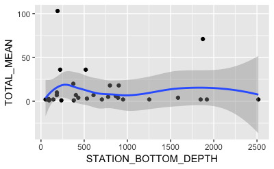

```r
total_stations <- stations_yr %>%
                  group_by( year) %>%
                  summarise( total_st= length(STATION))
# plot total number caught per depth note this is only for one year, would otherwise need to use catch and take the mean catch --note this example is only for one year
ggplot(data = species_yr) +
  geom_point(aes(x=STATION_BOTTOM_DEPTH, y=TOTAL_MEAN))+
  geom_smooth(aes(x=STATION_BOTTOM_DEPTH, y=TOTAL_MEAN))
```

**NOTE** For those years where we surveyed North of our typical sites (ex. Oregon and Washington), these values are cut out of the map. In order to add these to the map, or in general to ensure that our zoom is focused on specific locations based on results, could use the following:

ylim<- c(min(species_year$LATITUDE)-1, max(species_year$LATITUDE)+1) xlim<- c(min(species_year$LONGITUDE)-1, max(species_year$LONGITUDE)+1) coord_sf(xlim= xlim , ylim= ylim, crs = 4326)+ # specifies our spp specific distribution and ensure correct projection info– going to try static values this round

I am purposely choosing to keep the current boundaries that I have because I like the standardized maps, but these could def be easily altered in the future!

*NOTE* I originally planned to plot these graphs with the package {ggmap}, function getmap()–but it returned maps that did not project properly with our point catch data. I was able to correctly project a .shp file of states, and the ocean basin and terrain in WGS84, but these maps were downloaded and stored in the directory.

*NOTE* I will eventually need to consider standardizing all of the catch values so that they are a standard scale, and not based on relative measures (for myctophid catch that is) as currently they are simply relative measures based on a given year’s catch (ie a large bubble on a plot may be smaller than another bubble for a different year)- I think it is fine for my purposes at this point but could be important for comparing myctophid catch in the future.

Note that I am finally trying to play around with converting this output into a shiny app. as of 08/20/18